# Stroop Effect

In a Stroop task, participants are presented with a list of words, with each word displayed in a color of ink. The participant’s task is to say out loud the color of the ink in which the word is printed. The task has two conditions: a congruent words condition, and an incongruent words condition. In the congruent words condition, the words being displayed are color words whose names match the colors in which they are printed: for example RED, BLUE. In the incongruent words condition, the words displayed are color words whose names do not match the colors in which they are printed: for example PURPLE, ORANGE. In each case, we measure the time it takes to name the ink colors in equally-sized lists. Each participant will go through and record a time from each condition.

**Test Results**:

Congruent words - 12.65

Incongruent words - 15.38

**1. What is our independent variable? What is our dependent variable?**

- Independent variable is: The word/colour congruency that is the variable being manipulated in the experiment
- Dependent variable is: The time taken by recognize/name the ink colors of the mismatch word/colour congruency

**2. What is an appropriate set of hypotheses for this task? What kind of statistical test do you expect to perform? Justify your choices.**

```
Null Hypothsis, H0 - The mismatch of color to word will have no effect or decrease time to recognize and say the color

Alternate Hypothesis, H1 - The mismatch of color to word will increase time to recognize and say the color

H0: μi ≤ μc (μi - population mean of incongruent values, μc - population mean of congruent values)

H1: μi > μc (μi - population mean of incongruent values, μc - population mean of congruent values)
```

**statistical test choices**

```
95% confidence interval
```

**Paired one tail t-test** -> with two tests per participant this test show if the mean of incongruent words is statistically significantly different from the congruent words at an alpha of 0.05.

**Reason(s)**: Here t-test need to be performed instead of a z-test because

> 1) the population standard deviation is unknown; and

> 2) the sample set is less than 30. The t-test will be a one tailed t-test i.e. directional alternative hypothesis is that participant's incongruent sample mean will be larger than the participant's congruent sample mean.

```
A paired t-test (or dependent sample test), will be used because the data set is of one group of participants tested twice under different conditions (word/colour congruency). This will also facilitate either rejecting or accepting the null hypothesis.
```

**3. Report some descriptive statistics regarding this dataset. Include at least one measure of central tendency and at least one measure of variability.**

```
sample size = 24

mean: $xbar = \Sigma{x}/n$ (where xbar is the sample mean, x is the value and n is the number of samples)

Congruent: 14.05, Incogruent: 22.02

median: as the data seems slightly positively skewed, median is a better representation of central tendency

Congruent: 14.3565, Incongruent: 21.0175

sample std. deviation: $\sigma = \Sigma{(x - xbar)^2}/n$

Congruent: 3.56, Incongruent: 4.80
```

```python
# Render our plots inline# Rende
%matplotlib inline

import matplotlib.pyplot as plt
import pandas as pd
import numpy as np

stroop = pd.read_csv("stroopdata.csv")
```

```python
# dataset
print(stroop)
```

```
    Congruent  Incongruent
0      12.079       19.278
1      16.791       18.741
2       9.564       21.214
3       8.630       15.687
4      14.669       22.803
5      12.238       20.878
6      14.692       24.572
7       8.987       17.394
8       9.401       20.762
9      14.480       26.282
10     22.328       24.524
11     15.298       18.644
12     15.073       17.510
13     16.929       20.330
14     18.200       35.255
15     12.130       22.158
16     18.495       25.139
17     10.639       20.429
18     11.344       17.425
19     12.369       34.288
20     12.944       23.894
21     14.233       17.960
22     19.710       22.058
23     16.004       21.157
```

```python
# descriptive stats
stroop.describe()
```

|  | Congruent | Incongruent |
| --- | --- | --- |
| count | 24.000000 | 24.000000 |
| mean | 14.051125 | 22.015917 |
| std | 3.559358 | 4.797057 |
| min | 8.630000 | 15.687000 |
| 25% | 11.895250 | 18.716750 |
| 50% | 14.356500 | 21.017500 |
| 75% | 16.200750 | 24.051500 |
| max | 22.328000 | 35.255000 |

```python
# median / 50% values
congruent = stroop['Congruent']
incongruent = stroop['Incongruent']
congruent.median(), incongruent.median()
```

```
(14.3565, 21.0175)
```

**4.Provide one or two visualizations that show the distribution of the sample data. Write one or two sentences noting what you observe about the plot or plots.**

**Plots** Please see below a histogram which show the distribution of data from both congruent and incongruent conditions.

**Observations** From histogram plots, although both graphs visually appear somewhat positively skewed, the mean is pretty close to the peak in both graphs which would indicate a normal distribution. Provided these are samples from the population, the sampling mean would be similar to the population mean.

[output not shown]

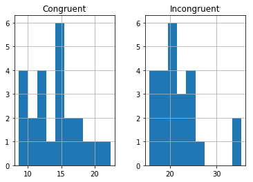

```python
data =  np.genfromtxt('stroopdata.csv', delimiter=',',dtype=np.float32)

# histogram
stroop.hist()
```

**5.Now, perform the statistical test and report your results. What is your confidence level and your critical statistic value? Do you reject the null hypothesis or fail to reject it? Come to a conclusion in terms of the experiment task. Did the results match up with your expectations?**

**Point Estimate**, dbar = $\Sigma (xi − xc)/n$ = 7.964

xi is incongruent, xc is the congruent values, n is the sample set

**standard deviation**, sd = 4.86

standard error of the difference, SE(dbar) = sd/√n = 4.86/√24 = 0.99

**t-statistic**, T = dbar/SE(dbar) = 7.964/0.99 = 8.04 on 23df

- **Why is your p-value positive? We are doing congruent is less than incongruent, so it should be congruent - incongruent, correct?**

  Because as per our null hypothesis, μi ≤ μc (μi - population mean of incongruent values, μc - population mean of congruent values) And based on our null hypothesis we calculated Point Estimates and standard deviation. (Please refer corrected values from "stroopdata_processed.csv")

t-distribution with n-1 degrees of freedom (df = 23). Using the t-distribution table to find p-value...

The value of **p < 0.0001**. The result is significant at p < 0.05%

**Result**

Reject the null hypothesis, the word/colour incongruent does cause a greater time response

**Conclusion**

The results match my expectations.

```python
stroop = pd.read_csv("stroopdata_processed.csv")
print(stroop)
```

```
    Congruent  Incongruent  Difference  Point Estimate  StandardDeviation
0   12.079000    19.278000      -7.199       -7.964792           4.864827
1   16.791000    18.741000      -1.950             NaN                NaN
2    9.564000    21.214000     -11.650             NaN                NaN
3    8.630000    15.687000      -7.057             NaN                NaN
4   14.669000    22.803000      -8.134             NaN                NaN
5   12.238000    20.878000      -8.640             NaN                NaN
6   14.692000    24.572000      -9.880             NaN                NaN
7    8.987000    17.394000      -8.407             NaN                NaN
8    9.401000    20.762000     -11.361             NaN                NaN
9   14.480000    26.282000     -11.802             NaN                NaN
10  22.328000    24.524000      -2.196             NaN                NaN
11  15.298000    18.644000      -3.346             NaN                NaN
12  15.073000    17.510000      -2.437             NaN                NaN
13  16.929000    20.330000      -3.401             NaN                NaN
14  18.200000    35.255000     -17.055             NaN                NaN
15  12.130000    22.158000     -10.028             NaN                NaN
16  18.495000    25.139000      -6.644             NaN                NaN
17  10.639000    20.429000      -9.790             NaN                NaN
18  11.344000    17.425000      -6.081             NaN                NaN
19  12.369000    34.288000     -21.919             NaN                NaN
20  12.944000    23.894000     -10.950             NaN                NaN
21  14.233000    17.960000      -3.727             NaN                NaN
22  19.710000    22.058000      -2.348             NaN                NaN
23  16.004000    21.157000      -5.153             NaN                NaN
24  14.051125    22.015917         NaN             NaN                NaN
```

**6.Optional: What is responsible for the observed effects? What could be an alternative or similar task that would result in a similar effect? Some research about the problem will be helpful for thinking about these two questions!**

- Incongruent word/colour does cause a greater time response because it takes effort twice: one, to read word and two, to replace the color effect(which is recognized subconsciously).
- Replacing letters with numbers in the experiment would result in a similar effect.

  **Another similar task**: Being shown a list of words and asking the user to type (on a qwerty keyboard) commonly used words. First, use a list words with no spelling mistakes and then the same list of words withmisspelling. The reflects of knowing where the keys are positioned and the knowledge of the correctly spelt word would cause the users to recognize fast for correctly spelt words and a longer time to recognize that the word is spelt incorrectly, since change their habitual behaviour, causing a lag and longer time to complete the word.

```python
from subprocess import call
call(['python', '-m', 'nbconvert', 'stroopdata.ipynb'])
```